# Toolbox

Zhejun Zhang

4/27/2017

# Introduction

### Background

Capital Bikeshare is a bicycle sharing system that serves Washington, D.C. and its surrounding areas. It has more than 350 stations and 3,000 bicycles, all owned by local government and operated in a public-private partnership with Alta Bicycle Share. Opened in September 2010, the system was the largest bike sharing service in the United States until May 2013. Customers can check out a bike for their trip to work, Metro, go shopping, or visiting friends or families. A visiting pass or a membership will give the customer access to any bikes 24 hours a day, 365 days a year at any stations.

### Data

Original data comes from: https://archive.ics.uci.edu/ml/datasets/Bike+Sharing+Dataset

```r
library(pastecs)
```

```r
library(MASS)
library(ggplot2)
df <- read.csv("~/Desktop/Graduate/r programming/toolbox/Zhejun Zhang Winter data.csv",
               header=T, row.names = 1 ,sep=",", stringsAsFactors = F)
##View(df)
```

### Objectives

By analyzing this dataset, my objectives are as follows:

1. predicting the number of rental bikes at a particular time, measuring the optimal number of bikes that should be provided for any particular hours in winter
2. find the most suitable time for bike maintenance in winter

# Data Cleaning

First of all, one of the data issue I have is mis-formatted data. Variable “dteday” which indicates the date of the data that extract in year-month-day format. However, this format could not be well processed in my analysis. So it is necessary to change the string format to numeric if possible. Secondly, some of the variables might not be useful toward the problem that I want to solve in my proposal. For example, the variable “instant” which shows the sequence of each data points are not useful when thinking about the question I want to solve for this project. Those variables are not related to my questions and should be removed in order to simplified the data. Finally, there could be invalid data, typos, wrong data types sort of problems in this dataset. So I excluded variable “dteday”, “yr” and “season” in JMP, and make sure that they will not be used as record and never been used to building model in future projects.

```r
df$dteday <- NULL
df$season <- NULL
df$yr <- NULL
data_new <- df
```

```r
cor(data_new)
```

```
##                    mnth           hr      holiday     weekday   workingday
## mnth        1.000000000 -0.005013194  0.073615996  0.05835466 -0.039584551
## hr         -0.005013194  1.000000000  0.001532055 -0.00591967  0.006993954
## holiday     0.073615996  0.001532055  1.000000000 -0.18389039 -0.278565439
## weekday     0.058354657 -0.005919670 -0.183890392  1.00000000  0.071643274
## workingday -0.039584551  0.006993954 -0.278565439  0.07164327  1.000000000
## weathersit  0.051869520 -0.039388380  0.023464328  0.06801080  0.049713034
## temp        0.098589462  0.199658663 -0.063657822  0.09062564  0.086626199
## atemp       0.087382380  0.178575555 -0.076258302  0.09777381  0.100273226
## hum         0.100025179 -0.227220452 -0.039074330  0.04099536  0.057158998
## windspeed   0.007108992  0.112761293  0.040724598  0.01147447 -0.067355720
## casual      0.029848790  0.192285325 -0.008848553  0.02015662 -0.211954652
## registered -0.067920841  0.311583836 -0.072769693  0.03444795  0.166385894
## cnt        -0.052570280  0.316997892 -0.065727960  0.03479268  0.096801454
##              weathersit         temp        atemp         hum    windspeed
## mnth        0.051869520  0.098589462  0.087382380  0.10002518  0.007108992
## hr         -0.039388380  0.199658663  0.178575555 -0.22722045  0.112761293
## holiday     0.023464328 -0.063657822 -0.076258302 -0.03907433  0.040724598
## weekday     0.068010797  0.090625643  0.097773805  0.04099536  0.011474466
## workingday  0.049713034  0.086626199  0.100273226  0.05715900 -0.067355720
## weathersit  1.000000000 -0.005394066  0.009019505  0.48262794 -0.106745823
## temp       -0.005394066  1.000000000  0.979429007 -0.08041139  0.143165747
## atemp       0.009019505  0.979429007  1.000000000 -0.02871563 -0.003661716
## hum         0.482627941 -0.080411391 -0.028715634  1.00000000 -0.341363843
## windspeed  -0.106745823  0.143165747 -0.003661716 -0.34136384  1.000000000
## casual     -0.135742504  0.469818733  0.453564266 -0.20592174  0.069259180
## registered -0.132866068  0.386210590  0.371532573 -0.18449875  0.071209406
## cnt        -0.147555456  0.446242200  0.429651478 -0.20891121  0.078277825
##                  casual  registered         cnt
## mnth        0.029848790 -0.06792084 -0.05257028
## hr          0.192285325  0.31158384  0.31699789
## holiday    -0.008848553 -0.07276969 -0.06572796
## weekday     0.020156622  0.03444795  0.03479268
## workingday -0.211954652  0.16638589  0.09680145
## weathersit -0.135742504 -0.13286607 -0.14755546
## temp        0.469818733  0.38621059  0.44624220
## atemp       0.453564266  0.37153257  0.42965148
## hum        -0.205921744 -0.18449875 -0.20891121
## windspeed   0.069259180  0.07120941  0.07827783
## casual      1.000000000  0.44870823  0.62306774
## registered  0.448708228  1.00000000  0.97858209
## cnt         0.623067741  0.97858209  1.00000000
```

We can see cnt’s distribution here to better help us understand the dataset. There are also some general information available for us to take a look.

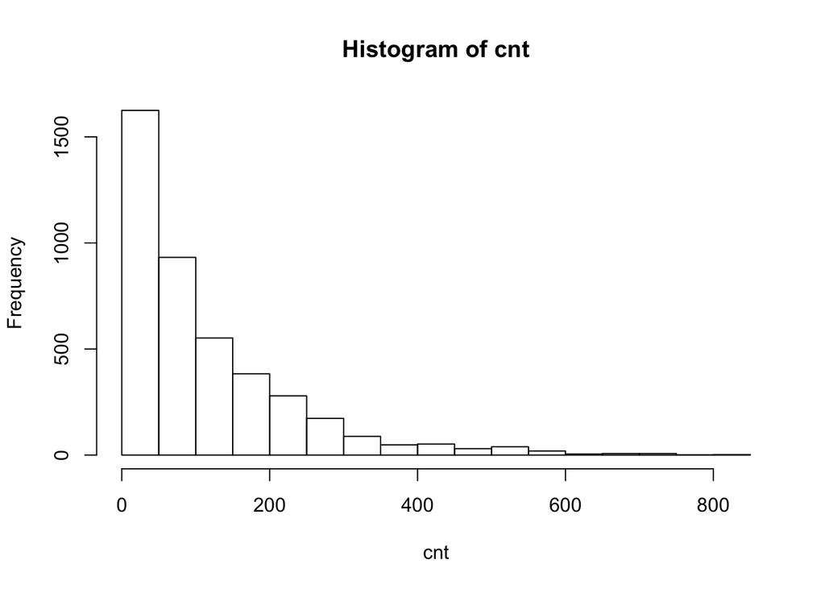

```r
hist(data_new$cnt,
     main = "Histogram of cnt",
     xlab = "cnt")
```

```r
stat.desc(data_new$cnt)
```

```
##      nbr.val     nbr.null       nbr.na          min          max
## 4.242000e+03 0.000000e+00 0.000000e+00 1.000000e+00 8.010000e+02
##        range          sum       median         mean      SE.mean
## 8.000000e+02 4.713480e+05 7.600000e+01 1.111146e+02 1.830537e+00
## CI.mean.0.95          var      std.dev     coef.var
## 3.588810e+00 1.421436e+04 1.192240e+02 1.072983e+00
```

# Data Analysis & Modeling

### Four Sub-models

I also discarded variables casual and registered. They indicate whether the bike renter was a registered user with the company (registered) or whether the bike renter was not registered with the company and was just casually using the bike (casual). The sum of those values are equal to the total count.

```r
data_scatter <- data_new
data_new$casual <- NULL
data_new$registered <- NULL
data_new$holiday <- NULL
#data_new[, c('casual', 'registered', 'holiday')] <- NULL
morning_index <- data_new$workingday == 1 & data_new$hr >=5 & data_new$hr <= 8
evening_index <- data_new$workingday == 1 & data_new$hr >= 17 & data_new$hr <= 20
normal_index <- (data_new$workingday == 1) & (!morning_index) & (!evening_index)

data1 <- data_new[morning_index, ]
data2 <- data_new[evening_index, ]
data3 <- data_new[normal_index, ]
data4 <- data_new[data_new$workingday ==0,]
```

### Scatter Matrix

I also ran a scatter matrix to check any possible correlation.

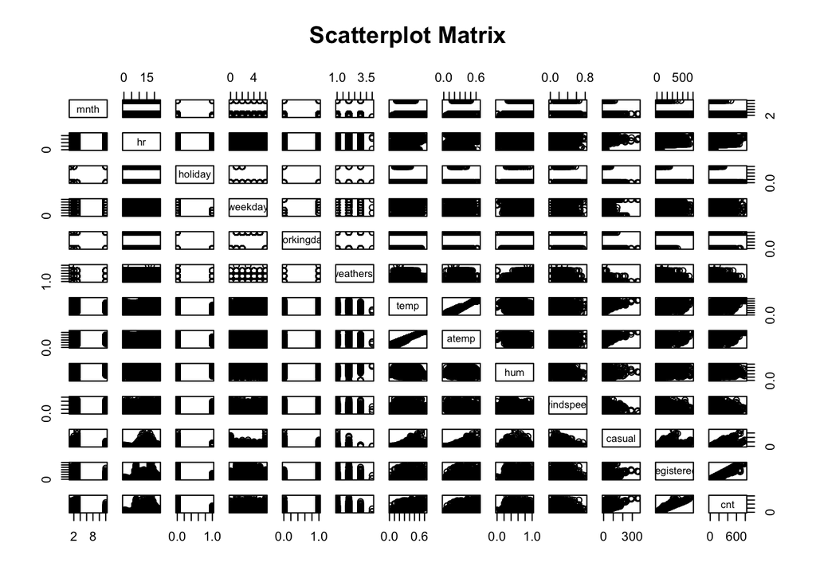

```r
par(mar=c(2,2,2,2))
pairs(~.,data=data_scatter,
      main="Scatterplot Matrix")
```

Based on the scatter matrix, there is a significant positive relationship between temp and atemp. They may be highly correlated.

### Box-cox Transformation

When I first built linear models based on OLS, I found that they are not perfectly normally distributed, the distribution for each model is either positive skewed or negative skewed. In this case, I tried to implement box-cox transformation for response variable count in order to make it normally distributed.

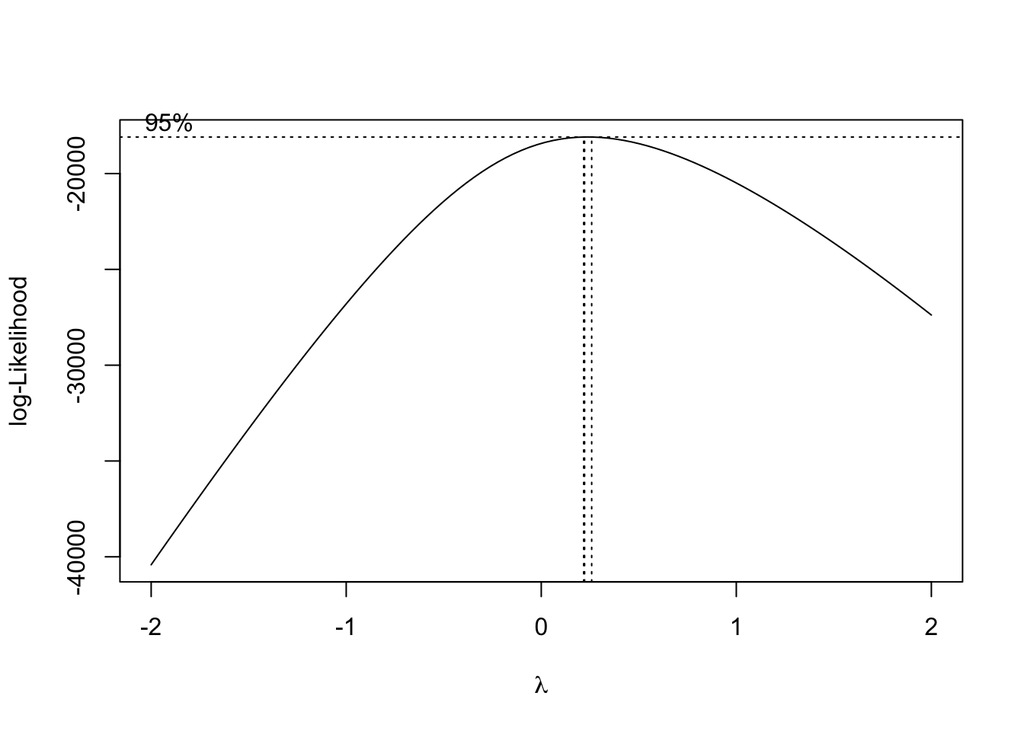

```r
boxcox(cnt ~ ., data = data_new)
```

Figure shows that boxcox selects the transformation alpha = 0.25 with a narrow confidence interval, but 0 does not locate in the narrow confidence interval, so we should use transformation: (cnt^0.25-1)/0.25

### Four Linear Models

Here are Four models:

```r
# Model1
data1$cnt <- (data1$cnt^(0.25)-1)/0.25
lm1 <- lm(cnt ~., data = data1)
summary(lm1)
```

```
##
## Call:
## lm(formula = cnt ~ ., data = data1)
##
## Residuals:
##     Min      1Q  Median      3Q     Max
## -5.8539 -1.1405  0.0733  1.2236  3.4640
##
## Coefficients: (1 not defined because of singularities)
##              Estimate Std. Error t value Pr(>|t|)
## (Intercept) -12.35941    0.64569 -19.141  < 2e-16 ***
## mnth         -0.12302    0.02262  -5.440 8.67e-08 ***
## hr            3.14520    0.06468  48.627  < 2e-16 ***
## weekday      -0.03224    0.05323  -0.606  0.54507
## workingday         NA         NA      NA       NA
## weathersit   -0.97691    0.12074  -8.091 5.27e-15 ***
## temp         13.94727    5.24431   2.660  0.00810 **
## atemp        -4.05350    5.59783  -0.724  0.46936
## hum           0.15911    0.50417   0.316  0.75245
## windspeed    -3.24683    1.20325  -2.698  0.00722 **
## ---
## Signif. codes:  0 '***' 0.001 '**' 0.01 '*' 0.05 '.' 0.1 ' ' 1
##
## Residual standard error: 1.565 on 462 degrees of freedom
## Multiple R-squared:  0.8459, Adjusted R-squared:  0.8432
## F-statistic:   317 on 8 and 462 DF,  p-value: < 2.2e-16
```

```r
# Model2
data2$cnt <- (data2$cnt^(0.25)-1)/0.25
lm2 <- lm(cnt ~., data = data2)
summary(lm2)
```

```
##
## Call:
## lm(formula = cnt ~ ., data = data2)
##
## Residuals:
##     Min      1Q  Median      3Q     Max
## -4.5310 -0.9881  0.0208  1.1548  4.1678
##
## Coefficients: (1 not defined because of singularities)
##             Estimate Std. Error t value Pr(>|t|)
## (Intercept) 26.17539    1.21167  21.603  < 2e-16 ***
## mnth        -0.13618    0.02173  -6.266 8.41e-10 ***
## hr          -0.89262    0.06253 -14.275  < 2e-16 ***
## weekday     -0.08276    0.04902  -1.688 0.092035 .
## workingday        NA         NA      NA       NA
## weathersit  -0.56625    0.12705  -4.457 1.04e-05 ***
## temp        16.48883    3.85463   4.278 2.29e-05 ***
## atemp       -5.25721    3.95346  -1.330 0.184240
## hum         -1.04251    0.44571  -2.339 0.019755 *
## windspeed   -2.02862    0.60122  -3.374 0.000802 ***
## ---
## Signif. codes:  0 '***' 0.001 '**' 0.01 '*' 0.05 '.' 0.1 ' ' 1
##
## Residual standard error: 1.481 on 468 degrees of freedom
## Multiple R-squared:  0.6568, Adjusted R-squared:  0.6509
## F-statistic:   112 on 8 and 468 DF,  p-value: < 2.2e-16
```

```r
# Model3
data3$cnt <- (data3$cnt^(0.25)-1)/0.25
lm3 <- lm(cnt ~., data = data3)
summary(lm3)
```

```
##
## Call:
## lm(formula = cnt ~ ., data = data3)
##
## Residuals:
##    Min     1Q Median     3Q    Max
## -6.362 -1.977  0.045  1.785  8.200
##
## Coefficients: (1 not defined because of singularities)
##              Estimate Std. Error t value Pr(>|t|)
## (Intercept)  2.802166   0.348508   8.040 1.59e-15 ***
## mnth         0.003507   0.019009   0.185   0.8536
## hr           0.245595   0.008666  28.340  < 2e-16 ***
## weekday      0.098707   0.044179   2.234   0.0256 *
## workingday         NA         NA      NA       NA
## weathersit  -0.220781   0.103478  -2.134   0.0330 *
## temp        15.237327   3.723344   4.092 4.45e-05 ***
## atemp       -6.030679   3.832980  -1.573   0.1158
## hum         -2.695835   0.366882  -7.348 3.01e-13 ***
## windspeed   -0.822721   0.649217  -1.267   0.2052
## ---
## Signif. codes:  0 '***' 0.001 '**' 0.01 '*' 0.05 '.' 0.1 ' ' 1
##
## Residual standard error: 2.604 on 1837 degrees of freedom
## Multiple R-squared:  0.4699, Adjusted R-squared:  0.4676
## F-statistic: 203.6 on 8 and 1837 DF,  p-value: < 2.2e-16
```

```r
# Model4
data4$cnt <- (data4$cnt^(0.25)-1)/0.25
lm4 <- lm(cnt ~., data = data4)
summary(lm4)
```

```
##
## Call:
## lm(formula = cnt ~ ., data = data4)
##
## Residuals:
##     Min      1Q  Median      3Q     Max
## -9.0499 -1.8908  0.1474  1.8661  7.0789
##
## Coefficients: (1 not defined because of singularities)
##              Estimate Std. Error t value Pr(>|t|)
## (Intercept)   4.92755    0.41491  11.876  < 2e-16 ***
## mnth         -0.12094    0.01944  -6.222 6.42e-10 ***
## hr            0.16628    0.01050  15.834  < 2e-16 ***
## weekday       0.06097    0.02454   2.484 0.013100 *
## workingday         NA         NA      NA       NA
## weathersit   -0.46949    0.13687  -3.430 0.000621 ***
## temp         35.88479    4.52382   7.932 4.28e-15 ***
## atemp       -23.54690    4.56676  -5.156 2.87e-07 ***
## hum          -3.16216    0.47373  -6.675 3.52e-11 ***
## windspeed    -3.10414    0.80234  -3.869 0.000114 ***
## ---
## Signif. codes:  0 '***' 0.001 '**' 0.01 '*' 0.05 '.' 0.1 ' ' 1
##
## Residual standard error: 2.657 on 1439 degrees of freedom
## Multiple R-squared:  0.4286, Adjusted R-squared:  0.4254
## F-statistic: 134.9 on 8 and 1439 DF,  p-value: < 2.2e-16
```

Based on our results, we found that the most important factor that affect bike usage is hour. By splitting into four different sub-model, we found that hour do have a linear relation with the variable count.

The results are reasonable as there are no rush hours during the weekend. Instead, temperature and humidity become two important factors since people are more willing to do outdoor activities during the weekend, and good weather is the prerequisite for any outdoor activities.

# Data Visaulization

Here is the scatter plot of bike count and hour using temperature as color indicator

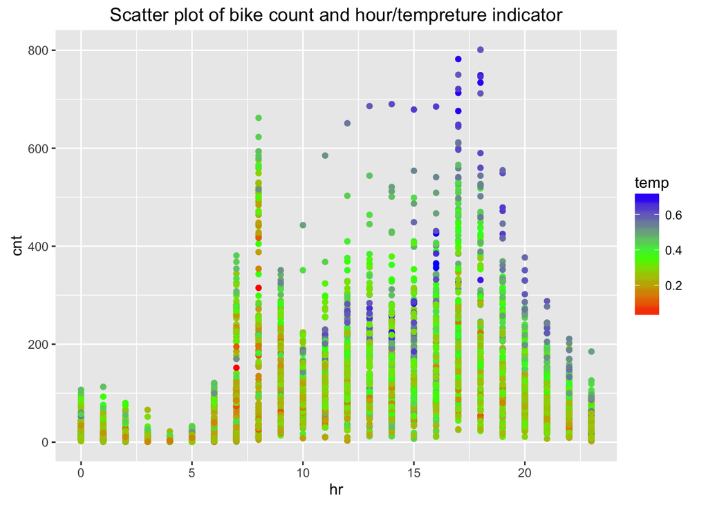

```r
# Scatter plot
scatter1 <- ggplot(data_new, aes(x = hr,
                                y = cnt,
                                color = temp)) + geom_point()
scatter1 + scale_color_gradientn(colours = rainbow(3))+ labs(title = "Scatter plot of bike count and hour/tempreture indicator")
```

According to this figure, most bikes are rented out on mornings and evenings. Warm weather in winter is suitable for riding a bike.

Here is the scatter plot of bike count and hour using weather situation as color indicator

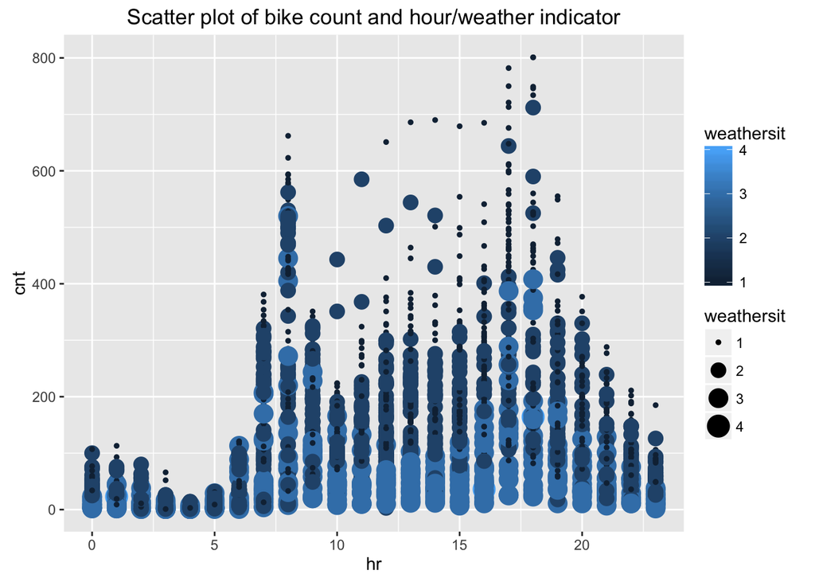

```r
scatter2 <- ggplot(data_new, aes(x = hr,
                                y = cnt,
                                color = weathersit,
                                size=weathersit)) + geom_point()+ labs(title = "Scatter plot of bike count and hour/weather indicator")
scatter2
```

Based on this figure, we can see that more bikes are rented on good weather. Severe weather is a strong indicator for low bike rentals.

Here is the heat map for bike count by weekday and hour

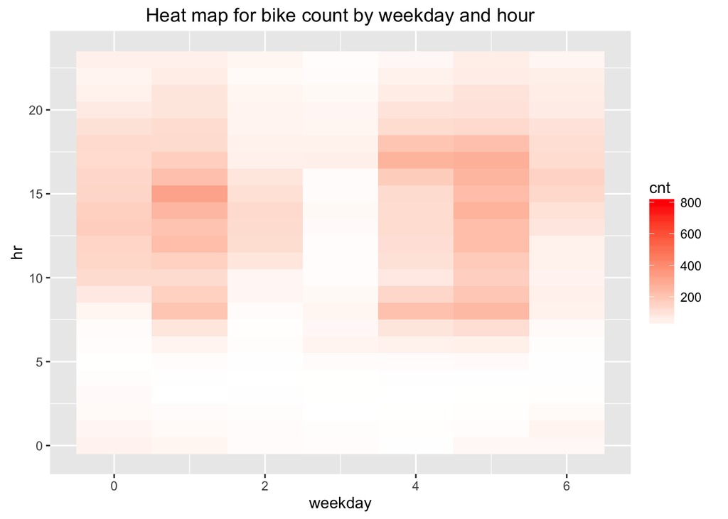

```r
heat <- ggplot(data_new, aes(x = weekday,
                             y = hr)) +
  geom_tile(aes(fill = cnt))
heat + scale_fill_gradient2(low="blue", high="red")+ labs(title = "Heat map for bike count by weekday and hour")
```

The heat map clearly shows time intervals that have high demands, which is a perfect tool for scheduling any maintenance activities.

# Conclusion

### Recoomended Actions

1. Based on our research results, we recommend the Capital Bike Sharing Program to schedule maintenance during the period from late night to early morning (10 pm to 5 am). If they must maintain bikes during daytime, then Tuesday 5 am - 8 am and Wednesday 10 am - 4 pm are appropriate.
2. To achieve overall efficiency, we also recommend the Capital Bike Sharing Program to modify the number of available bikes by calculating with our four sub-models that can be found in the results section. It is necessary for the program to pay special attention on those ‘peak time’.
3. For further research and more accurate prediction, we recommend collecting more samples from a much longer period that may cover more accurate data and more information. The two years data is not enough for building an accurate model with low residuals.
4. Any big events such as national day celebration and presidential inauguration would highly affect the bike usage. Because we cannot predict these big events and add them to our models, we expected to see high residuals of bike count when it happens. We recommended to record any big events that happened in D.C. so we can find the relations between bike usage and those events.

### Model Strength

1. These models are overall significant and accurate since we split them to four sub-models which can represent all four very different time period.
2. We have quantitative outcomes such as equations as our results. We can use the equation to make prediction or draw conclusion.

### Model Weakness

1. Any big events such as national day celebration and presidential inauguration would highly affect the bike usage. Because we cannot predict these big events and add them to our models, we expected to see high residuals of bike count when it happens.
2. The model is overall has a large residual. For further research and more accurate prediction, we recommend collecting more samples from a much longer period that may cover more accurate data and more information.